# 20171214_week_6_lab_task_2

"""Basics of Data Cleaning: http://lineardata.net/the-ultimate-guide-to-cleaning-data-in-python/

Happiness inside a Job: https://www.kaggle.com/harriken/clean-data-python/notebook https://github.com/Guillem-db/Happiness-inside-a-job-PyDataBcn17

Taser Data: https://trendct.org/2016/08/05/real-world-data-cleanup-with-python-and-pandas/ https://qxf2.com/blog/cleaning-data-python-pandas/ https://github.com/KarrieK/pandas_data_cleaning https://www.dataquest.io/blog/data-cleaning-with-python/ https://ssds.stanford.edu/python-tutorials-cleaning-and-scraping-data https://s3.amazonaws.com/assets.datacamp.com/production/course_3485/slides/ch5_slides.pdf https://stackoverflow.com/questions/13867294/cleaning-big-data-using-python https://www.kaggle.com/harriken/clean-data-python/notebook"""

""" DATA CLEANING A data scientist roughly spends about 70% of his time cleaning messy and unstructured data. If you are going to be spending this much time with one task you might as well know how to clean data well. This guide gives you a comprehensive step by step procedure when it comes to cleaning your data in Python.

http://lineardata.net/the-ultimate-guide-to-cleaning-data-in-python/ """

```python
import pandas as pd
df=pd.read_csv("/Users/yetkineser/Desktop/mef Python/week 6/listed_movies_2.csv")
df.head(2)
```

|  | budget | genres | homepage | id | keywords | original_language | original_title | overview | poplarity | production_companies | production_countries | release_date | revnue | runtime | spoken_languages | status | tagline | title | vote_average | vote_count |
| --- | --- | --- | --- | --- | --- | --- | --- | --- | --- | --- | --- | --- | --- | --- | --- | --- | --- | --- | --- | --- |
| 0 | 237000000 | [{"id": 28, "name": "Action"}, {"id": 12, "nam... | http://www.avatarmovie.com/ | 19995 | [{"id": 1463, "name": "culture clash"}, {"id":... | en | Avatar | In the 22nd century, a paraplegic Marine is di... | 150.437577 | [{"name": "Ingenious Film Partners", "id": 289... | [{"iso_3166_1": "US", "name": "United States o... | 10-12-09 | 2787965087 | 162.0 | [{"iso_639_1": "en", "name": "English"}, {"iso... | Released | Enter the World of Pandora. | Avatar | 7.2 | 11800 |
| 1 | 300000000 | [{"id": 12, "name": "Adventure"}, {"id": 14, "... | http://disney.go.com/disneypictures/pirates/ | 285 | [{"id": 270, "name": "ocean"}, {"id": 726, "na... | en | Pirates of the Caribbean: At World's End | Captain Barbossa, long believed to be dead, ha... | 139.082615 | [{"name": "Walt Disney Pictures", "id": 2}, {"... | [{"iso_3166_1": "US", "name": "United States o... | 19-05-07 | 961000000 | 169.0 | [{"iso_639_1": "en", "name": "English"}] | Released | At the end of the world, the adventure begins. | Pirates of the Caribbean: At World's End | 6.9 | 4500 |

```python
df.tail(2)
```

|  | budget | genres | homepage | id | keywords | original_language | original_title | overview | poplarity | production_companies | production_countries | release_date | revnue | runtime | spoken_languages | status | tagline | title | vote_average | vote_count |
| --- | --- | --- | --- | --- | --- | --- | --- | --- | --- | --- | --- | --- | --- | --- | --- | --- | --- | --- | --- | --- |
| 4801 | 0 | [] | http://shanghaicalling.com/ | 126186 | [] | en | Shanghai Calling | When ambitious New York attorney Sam is sent t... | 0.857008 | [] | [{"iso_3166_1": "US", "name": "United States o... | 03-05-12 | 0 | 98.0 | [{"iso_639_1": "en", "name": "English"}] | Released | A New Yorker in Shanghai | Shanghai Calling | 5.7 | 7 |
| 4802 | 0 | [{"id": 99, "name": "Documentary"}] | NaN | 25975 | [{"id": 1523, "name": "obsession"}, {"id": 224... | en | My Date with Drew | Ever since the second grade when he first saw ... | 1.929883 | [{"name": "rusty bear entertainment", "id": 87... | [{"iso_3166_1": "US", "name": "United States o... | 05-08-05 | 0 | 90.0 | [{"iso_639_1": "en", "name": "English"}] | Released | NaN | My Date with Drew | 6.3 | 16 |

```python
#df["work_time"] = df["Work_tym"]
#df.drop("Work_tym", 1)
```

"""After this we want to check if all the columns have the right data type associated with it. For example, sometimes a column that has numeric data might be stored as an ‘object’ type because it has a missing value stored as ‘missing’. To address this issue we need to first:"""

```python
df.info()
```

```
<class 'pandas.core.frame.DataFrame'>
RangeIndex: 4803 entries, 0 to 4802
Data columns (total 20 columns):
budget                  4803 non-null int64
genres                  4803 non-null object
homepage                1712 non-null object
id                      4803 non-null int64
keywords                4803 non-null object
original_language       4803 non-null object
original_title          4803 non-null object
overview                4800 non-null object
poplarity               4803 non-null float64
production_companies    4803 non-null object
production_countries    4803 non-null object
release_date            4802 non-null object
revnue                  4803 non-null int64
runtime                 4801 non-null float64
spoken_languages        4803 non-null object
status                  4803 non-null object
tagline                 3959 non-null object
title                   4803 non-null object
vote_average            4803 non-null float64
vote_count              4803 non-null int64
dtypes: float64(3), int64(4), object(13)
memory usage: 750.5+ KB
```

```python
# df['satisfaction_level'] = df['satisfaction_level'].astype('category')

df.shape
```

```
(4803, 20)
```

"""which returns the number of columns and rows in the datasets.

Another useful metric you could add to your initial exploration would be the frequency counts of each element in a particular column. We can implement this using the code shown below:"""

```python
df.genres.value_counts()
```

```
[{"id": 18, "name": "Drama"}]                                                                                                                                                                              370
[{"id": 35, "name": "Comedy"}]                                                                                                                                                                             282
[{"id": 18, "name": "Drama"}, {"id": 10749, "name": "Romance"}]                                                                                                                                            164
[{"id": 35, "name": "Comedy"}, {"id": 10749, "name": "Romance"}]                                                                                                                                           144
[{"id": 35, "name": "Comedy"}, {"id": 18, "name": "Drama"}]                                                                                                                                                142
[{"id": 35, "name": "Comedy"}, {"id": 18, "name": "Drama"}, {"id": 10749, "name": "Romance"}]                                                                                                              109
[{"id": 27, "name": "Horror"}, {"id": 53, "name": "Thriller"}]                                                                                                                                              88
[{"id": 99, "name": "Documentary"}]                                                                                                                                                                         68
[{"id": 27, "name": "Horror"}]                                                                                                                                                                              64
[{"id": 18, "name": "Drama"}, {"id": 53, "name": "Thriller"}]                                                                                                                                               62
[{"id": 18, "name": "Drama"}, {"id": 35, "name": "Comedy"}]                                                                                                                                                 46
[{"id": 80, "name": "Crime"}, {"id": 18, "name": "Drama"}, {"id": 53, "name": "Thriller"}]                                                                                                                  43
[{"id": 28, "name": "Action"}, {"id": 53, "name": "Thriller"}]                                                                                                                                              40
[{"id": 18, "name": "Drama"}, {"id": 36, "name": "History"}]                                                                                                                                                37
[{"id": 35, "name": "Comedy"}, {"id": 10751, "name": "Family"}]                                                                                                                                             36
[{"id": 28, "name": "Action"}, {"id": 35, "name": "Comedy"}]                                                                                                                                                36
[{"id": 18, "name": "Drama"}, {"id": 35, "name": "Comedy"}, {"id": 10749, "name": "Romance"}]                                                                                                               35
[{"id": 80, "name": "Crime"}, {"id": 18, "name": "Drama"}]                                                                                                                                                  33
[{"id": 35, "name": "Comedy"}, {"id": 80, "name": "Crime"}]                                                                                                                                                 30
[{"id": 28, "name": "Action"}, {"id": 80, "name": "Crime"}, {"id": 53, "name": "Thriller"}]                                                                                                                 30
[]                                                                                                                                                                                                          28
[{"id": 18, "name": "Drama"}, {"id": 80, "name": "Crime"}]                                                                                                                                                  26
[{"id": 16, "name": "Animation"}, {"id": 10751, "name": "Family"}]                                                                                                                                          25
[{"id": 28, "name": "Action"}, {"id": 80, "name": "Crime"}, {"id": 18, "name": "Drama"}, {"id": 53, "name": "Thriller"}]                                                                                    25
[{"id": 12, "name": "Adventure"}, {"id": 28, "name": "Action"}, {"id": 53, "name": "Thriller"}]                                                                                                             24
[{"id": 18, "name": "Drama"}, {"id": 10402, "name": "Music"}]                                                                                                                                               24
[{"id": 53, "name": "Thriller"}]                                                                                                                                                                            23
```

[output cut: 35 more lines]

"""STEP 2: Visualize your data I’m not asking you to visualize your data in great detail but I want you to understand if there are errors in terms of outliers. There are 3 fundamental visualizations that you must carry out 1.The Histogram: The histogram gives you a basic frequency count and allows you to determine weather a particular column is normally distributed or not. The code to plot a histogram is shown below:"""

```python
!pip install matplotlib
import matplotlib.pylot as plt
%matplotlib inline
import warnings
warnings.filterwarnings('ignore')
df.poplarity.plot('hist')
plt.show()
```

[output not shown]

```
---------------------------------------------------------------------------
ModuleNotFoundError                       Traceback (most recent call last)
<ipython-input-25-211ce5d54da0> in <module>()
      1 get_ipython().system('pip install matplotlib')
----> 2 import matplotlib.pylot as plt
      3 get_ipython().magic('matplotlib inline')
      4 import warnings
      5 warnings.filterwarnings('ignore')

ModuleNotFoundError: No module named 'matplotlib.pylot'
```

"""2. The boxplot A box plot is the best way to figure out if you have outliers in your dataset. It gives you the values of the 1st, 2nd and 3rd quartiles as well the median. In order to plot a box plot we need to follow the code below:"""

[figure not shown]

[figure not shown]

```python
import matplotlib.pyplot as plt

df.boxplot(column='poplarity', by='genres')
plt.show()
```

"""3. The scatterplot The scatterplot helps us visualize the relationship between two or more variables. The code needed to execute a scatterplot is shown below:"""

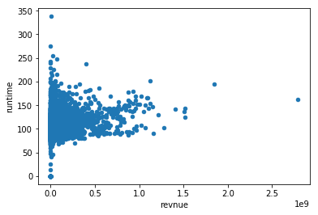

```python
import matplotlib.pyplot as plt

df.plot(kind='scatter', x='revnue', y='runtime')
plt.show()
```

"""STEP 3: Deal with your missing values Dealing with missing values is crucial because of it does not make sense to feed these missing values into a machine learning algorithm or a neural network. There are a couple of ways you could deal with missing values. The first method is to drop them completely from the entire dataset or from a particular column. The second method is to fill them with some summary statistic or a number or a string based on the problem at hand. In order to drop all the missing value from a dataframe we use the code shown below:"""

```python
df.dropna()
```

|  | budget | genres | homepage | id | keywords | original_language | original_title | overview | poplarity | production_companies | production_countries | release_date | revnue | runtime | spoken_languages | status | tagline | title | vote_average | vote_count |
| --- | --- | --- | --- | --- | --- | --- | --- | --- | --- | --- | --- | --- | --- | --- | --- | --- | --- | --- | --- | --- |
| 0 | 237000000 | [{"id": 28, "name": "Action"}, {"id": 12, "nam... | http://www.avatarmovie.com/ | 19995 | [{"id": 1463, "name": "culture clash"}, {"id":... | en | Avatar | In the 22nd century, a paraplegic Marine is di... | 150.437577 | [{"name": "Ingenious Film Partners", "id": 289... | [{"iso_3166_1": "US", "name": "United States o... | 10-12-09 | 2787965087 | 162.0 | [{"iso_639_1": "en", "name": "English"}, {"iso... | Released | Enter the World of Pandora. | Avatar | 7.2 | 11800 |
| 1 | 300000000 | [{"id": 12, "name": "Adventure"}, {"id": 14, "... | http://disney.go.com/disneypictures/pirates/ | 285 | [{"id": 270, "name": "ocean"}, {"id": 726, "na... | en | Pirates of the Caribbean: At World's End | Captain Barbossa, long believed to be dead, ha... | 139.082615 | [{"name": "Walt Disney Pictures", "id": 2}, {"... | [{"iso_3166_1": "US", "name": "United States o... | 19-05-07 | 961000000 | 169.0 | [{"iso_639_1": "en", "name": "English"}] | Released | At the end of the world, the adventure begins. | Pirates of the Caribbean: At World's End | 6.9 | 4500 |
| 2 | 245000000 | [{"id": 28, "name": "Action"}, {"id": 12, "nam... | http://www.sonypictures.com/movies/spectre/ | 206647 | [{"id": 470, "name": "spy"}, {"id": 818, "name... | en | Spectre | A cryptic message from Bond’s past sends him o... | 107.376788 | [{"name": "Columbia Pictures", "id": 5}, {"nam... | [{"iso_3166_1": "GB", "name": "United Kingdom"... | 26-10-15 | 880674609 | 148.0 | [{"iso_639_1": "fr", "name": "Fran\u00e7ais"},... | Released | A Plan No One Escapes | Spectre | 6.3 | 4466 |
| 3 | 250000000 | [{"id": 28, "name": "Action"}, {"id": 80, "nam... | http://www.thedarkknightrises.com/ | 49026 | [{"id": 849, "name": "dc comics"}, {"id": 853,... | en | The Dark Knight Rises | Following the death of District Attorney Harve... | 112.312950 | [{"name": "Legendary Pictures", "id": 923}, {"... | [{"iso_3166_1": "US", "name": "United States o... | 16-07-12 | 1084939099 | 165.0 | [{"iso_639_1": "en", "name": "English"}] | Released | The Legend Ends | The Dark Knight Rises | 7.6 | 9106 |
| 4 | 260000000 | [{"id": 28, "name": "Action"}, {"id": 12, "nam... | http://movies.disney.com/john-carter | 49529 | [{"id": 818, "name": "based on novel"}, {"id":... | en | John Carter | John Carter is a war-weary, former military ca... | 43.926995 | [{"name": "Walt Disney Pictures", "id": 2}] | [{"iso_3166_1": "US", "name": "United States o... | 07-03-12 | 284139100 | 132.0 | [{"iso_639_1": "en", "name": "English"}] | Released | Lost in our world, found in another. | John Carter | 6.1 | 2124 |
| 5 | 258000000 | [{"id": 14, "name": "Fantasy"}, {"id": 28, "na... | http://www.sonypictures.com/movies/spider-man3/ | 559 | [{"id": 851, "name": "dual identity"}, {"id": ... | en | Spider-Man 3 | The seemingly invincible Spider-Man goes up ag... | 115.699814 | [{"name": "Columbia Pictures", "id": 5}, {"nam... | [{"iso_3166_1": "US", "name": "United States o... | 01-05-07 | 890871626 | 139.0 | [{"iso_639_1": "en", "name": "English"}, {"iso... | Released | The battle within. | Spider-Man 3 | 5.9 | 3576 |
| 6 | 260000000 | [{"id": 16, "name": "Animation"}, {"id": 10751... | http://disney.go.com/disneypictures/tangled/ | 38757 | [{"id": 1562, "name": "hostage"}, {"id": 2343,... | en | Tangled | When the kingdom's most wanted-and most charmi... | 48.681969 | [{"name": "Walt Disney Pictures", "id": 2}, {"... | [{"iso_3166_1": "US", "name": "United States o... | 24-11-10 | 591794936 | 100.0 | [{"iso_639_1": "en", "name": "English"}] | Released | They're taking adventure to new lengths. | Tangled | 7.4 | 3330 |
| 7 | 280000000 | [{"id": 28, "name": "Action"}, {"id": 12, "nam... | http://marvel.com/movies/movie/193/avengers_ag... | 99861 | [{"id": 8828, "name": "marvel comic"}, {"id": ... | en | Avengers: Age of Ultron | When Tony Stark tries to jumpstart a dormant p... | 134.279229 | [{"name": "Marvel Studios", "id": 420}, {"name... | [{"iso_3166_1": "US", "name": "United States o... | 22-04-15 | 1405403694 | 141.0 | [{"iso_639_1": "en", "name": "English"}] | Released | A New Age Has Come. | Avengers: Age of Ultron | 7.3 | 6767 |
| 8 | 250000000 | [{"id": 12, "name": "Adventure"}, {"id": 14, "... | http://harrypotter.warnerbros.com/harrypottera... | 767 | [{"id": 616, "name": "witch"}, {"id": 2343, "n... | en | Harry Potter and the Half-Blood Prince | As Harry begins his sixth year at Hogwarts, he... | 98.885637 | [{"name": "Warner Bros.", "id": 6194}, {"name"... | [{"iso_3166_1": "GB", "name": "United Kingdom"... | 07-07-09 | 933959197 | 153.0 | [{"iso_639_1": "en", "name": "English"}] | Released | Dark Secrets Revealed | Harry Potter and the Half-Blood Prince | 7.4 | 5293 |
| 9 | 250000000 | [{"id": 28, "name": "Action"}, {"id": 12, "nam... | http://www.batmanvsupermandawnofjustice.com/ | 209112 | [{"id": 849, "name": "dc comics"}, {"id": 7002... | en | Batman v Superman: Dawn of Justice | Fearing the actions of a god-like Super Hero l... | 155.790452 | [{"name": "DC Comics", "id": 429}, {"name": "A... | [{"iso_3166_1": "US", "name": "United States o... | 23-03-16 | 873260194 | 151.0 | [{"iso_639_1": "en", "name": "English"}] | Released | Justice or revenge | Batman v Superman: Dawn of Justice | 5.7 | 7004 |
| 11 | 200000000 | [{"id": 12, "name": "Adventure"}, {"id": 28, "... | http://www.mgm.com/view/movie/234/Quantum-of-S... | 10764 | [{"id": 627, "name": "killing"}, {"id": 1568, ... | en | Quantum of Solace | Quantum of Solace continues the adventures of ... | 107.928811 | [{"name": "Eon Productions", "id": 7576}] | [{"iso_3166_1": "GB", "name": "United Kingdom"... | 30-10-08 | 586090727 | 106.0 | [{"iso_639_1": "en", "name": "English"}, {"iso... | Released | For love, for hate, for justice, for revenge. | Quantum of Solace | 6.1 | 2965 |
| 12 | 200000000 | [{"id": 12, "name": "Adventure"}, {"id": 14, "... | http://disney.go.com/disneypictures/pirates/ | 58 | [{"id": 616, "name": "witch"}, {"id": 663, "na... | en | Pirates of the Caribbean: Dead Man's Chest | Captain Jack Sparrow works his way out of a bl... | 145.847379 | [{"name": "Walt Disney Pictures", "id": 2}, {"... | [{"iso_3166_1": "JM", "name": "Jamaica"}, {"is... | 20-06-06 | 1065659812 | 151.0 | [{"iso_639_1": "en", "name": "English"}, {"iso... | Released | Jack is back! | Pirates of the Caribbean: Dead Man's Chest | 7.0 | 5246 |
| 13 | 255000000 | [{"id": 28, "name": "Action"}, {"id": 12, "nam... | http://disney.go.com/the-lone-ranger/ | 57201 | [{"id": 1556, "name": "texas"}, {"id": 2673, "... | en | The Lone Ranger | The Texas Rangers chase down a gang of outlaws... | 49.046956 | [{"name": "Walt Disney Pictures", "id": 2}, {"... | [{"iso_3166_1": "US", "name": "United States o... | 03-07-13 | 89289910 | 149.0 | [{"iso_639_1": "en", "name": "English"}] | Released | Never Take Off the Mask | The Lone Ranger | 5.9 | 2311 |
| 14 | 225000000 | [{"id": 28, "name": "Action"}, {"id": 12, "nam... | http://www.manofsteel.com/ | 49521 | [{"id": 83, "name": "saving the world"}, {"id"... | en | Man of Steel | A young boy learns that he has extraordinary p... | 99.398009 | [{"name": "Legendary Pictures", "id": 923}, {"... | [{"iso_3166_1": "GB", "name": "United Kingdom"... | 12-06-13 | 662845518 | 143.0 | [{"iso_639_1": "en", "name": "English"}] | Released | You will believe that a man can fly. | Man of Steel | 6.5 | 6359 |
| 16 | 220000000 | [{"id": 878, "name": "Science Fiction"}, {"id"... | http://marvel.com/avengers_movie/ | 24428 | [{"id": 242, "name": "new york"}, {"id": 5539,... | en | The Avengers | When an unexpected enemy emerges and threatens... | 144.448633 | [{"name": "Paramount Pictures", "id": 4}, {"na... | [{"iso_3166_1": "US", "name": "United States o... | 25-04-12 | 1519557910 | 143.0 | [{"iso_639_1": "en", "name": "English"}] | Released | Some assembly required. | The Avengers | 7.4 | 11776 |
| 17 | 380000000 | [{"id": 12, "name": "Adventure"}, {"id": 28, "... | http://disney.go.com/pirates/index-on-stranger... | 1865 | [{"id": 658, "name": "sea"}, {"id": 1316, "nam... | en | Pirates of the Caribbean: On Stranger Tides | Captain Jack Sparrow crosses paths with a woma... | 135.413856 | [{"name": "Walt Disney Pictures", "id": 2}, {"... | [{"iso_3166_1": "US", "name": "United States o... | 14-05-11 | 1045713802 | 136.0 | [{"iso_639_1": "en", "name": "English"}, {"iso... | Released | Live Forever Or Die Trying. | Pirates of the Caribbean: On Stranger Tides | 6.4 | 4948 |
| 18 | 225000000 | [{"id": 28, "name": "Action"}, {"id": 35, "nam... | http://www.sonypictures.com/movies/meninblack3/ | 41154 | [{"id": 4379, "name": "time travel"}, {"id": 5... | en | Men in Black 3 | Agents J (Will Smith) and K (Tommy Lee Jones) ... | 52.035179 | [{"name": "Amblin Entertainment", "id": 56}, {... | [{"iso_3166_1": "US", "name": "United States o... | 23-05-12 | 624026776 | 106.0 | [{"iso_639_1": "en", "name": "English"}] | Released | They are back... in time. | Men in Black 3 | 6.2 | 4160 |
| 19 | 250000000 | [{"id": 28, "name": "Action"}, {"id": 12, "nam... | http://www.thehobbit.com/ | 122917 | [{"id": 417, "name": "corruption"}, {"id": 603... | en | The Hobbit: The Battle of the Five Armies | Immediately after the events of The Desolation... | 120.965743 | [{"name": "WingNut Films", "id": 11}, {"name":... | [{"iso_3166_1": "NZ", "name": "New Zealand"}, ... | 10-12-14 | 956019788 | 144.0 | [{"iso_639_1": "en", "name": "English"}] | Released | Witness the defining chapter of the Middle-Ear... | The Hobbit: The Battle of the Five Armies | 7.1 | 4760 |
| 20 | 215000000 | [{"id": 28, "name": "Action"}, {"id": 12, "nam... | http://www.theamazingspiderman.com | 1930 | [{"id": 1872, "name": "loss of father"}, {"id"... | en | The Amazing Spider-Man | Peter Parker is an outcast high schooler aband... | 89.866276 | [{"name": "Columbia Pictures", "id": 5}, {"nam... | [{"iso_3166_1": "US", "name": "United States o... | 27-06-12 | 752215857 | 136.0 | [{"iso_639_1": "en", "name": "English"}] | Released | The untold story begins. | The Amazing Spider-Man | 6.5 | 6586 |
| 21 | 200000000 | [{"id": 28, "name": "Action"}, {"id": 12, "nam... | http://www.robinhoodthemovie.com/ | 20662 | [{"id": 4147, "name": "robin hood"}, {"id": 43... | en | Robin Hood | When soldier Robin happens upon the dying Robe... | 37.668301 | [{"name": "Imagine Entertainment", "id": 23}, ... | [{"iso_3166_1": "GB", "name": "United Kingdom"... | 12-05-10 | 310669540 | 140.0 | [{"iso_639_1": "en", "name": "English"}, {"iso... | Released | Rise and rise again, until lambs become lions. | Robin Hood | 6.2 | 1398 |
| 22 | 250000000 | [{"id": 12, "name": "Adventure"}, {"id": 14, "... | http://www.thehobbit.com/ | 57158 | [{"id": 603, "name": "elves"}, {"id": 604, "na... | en | The Hobbit: The Desolation of Smaug | The Dwarves, Bilbo and Gandalf have successful... | 94.370564 | [{"name": "WingNut Films", "id": 11}, {"name":... | [{"iso_3166_1": "NZ", "name": "New Zealand"}, ... | 11-12-13 | 958400000 | 161.0 | [{"iso_639_1": "en", "name": "English"}] | Released | Beyond darkness... beyond desolation... lies t... | The Hobbit: The Desolation of Smaug | 7.6 | 4524 |
| 23 | 180000000 | [{"id": 12, "name": "Adventure"}, {"id": 14, "... | http://www.goldencompassmovie.com/index_german... | 2268 | [{"id": 392, "name": "england"}, {"id": 1461, ... | en | The Golden Compass | After overhearing a shocking secret, precociou... | 42.990906 | [{"name": "New Line Cinema", "id": 12}, {"name... | [{"iso_3166_1": "GB", "name": "United Kingdom"... | 04-12-07 | 372234864 | 113.0 | [{"iso_639_1": "is", "name": "\u00cdslenska"},... | Released | There are worlds beyond our own - the compass ... | The Golden Compass | 5.8 | 1303 |
| 25 | 200000000 | [{"id": 18, "name": "Drama"}, {"id": 10749, "n... | http://www.titanicmovie.com | 597 | [{"id": 2580, "name": "shipwreck"}, {"id": 298... | en | Titanic | 84 years later, a 101-year-old woman named Ros... | 100.025899 | [{"name": "Paramount Pictures", "id": 4}, {"na... | [{"iso_3166_1": "US", "name": "United States o... | 18-11-97 | 1845034188 | 194.0 | [{"iso_639_1": "en", "name": "English"}, {"iso... | Released | Nothing on Earth could come between them. | Titanic | 7.5 | 7562 |
| 26 | 250000000 | [{"id": 12, "name": "Adventure"}, {"id": 28, "... | http://marvel.com/captainamericapremiere | 271110 | [{"id": 393, "name": "civil war"}, {"id": 6091... | en | Captain America: Civil War | Following the events of Age of Ultron, the col... | 198.372395 | [{"name": "Studio Babelsberg", "id": 264}, {"n... | [{"iso_3166_1": "US", "name": "United States o... | 27-04-16 | 1153304495 | 147.0 | [{"iso_639_1": "ro", "name": "Rom\u00e2n\u0103... | Released | Divided We Fall | Captain America: Civil War | 7.1 | 7241 |
| 28 | 150000000 | [{"id": 28, "name": "Action"}, {"id": 12, "nam... | http://www.jurassicworld.com/ | 135397 | [{"id": 1299, "name": "monster"}, {"id": 1718,... | en | Jurassic World | Twenty-two years after the events of Jurassic ... | 418.708552 | [{"name": "Universal Studios", "id": 13}, {"na... | [{"iso_3166_1": "US", "name": "United States o... | 09-06-15 | 1513528810 | 124.0 | [{"iso_639_1": "en", "name": "English"}] | Released | The park is open. | Jurassic World | 6.5 | 8662 |
| 29 | 200000000 | [{"id": 28, "name": "Action"}, {"id": 12, "nam... | http://www.skyfall-movie.com | 37724 | [{"id": 470, "name": "spy"}, {"id": 4289, "nam... | en | Skyfall | When Bond's latest assignment goes gravely wro... | 93.004993 | [{"name": "Columbia Pictures", "id": 5}] | [{"iso_3166_1": "GB", "name": "United Kingdom"... | 25-10-12 | 1108561013 | 143.0 | [{"iso_639_1": "en", "name": "English"}] | Released | Think on your sins. | Skyfall | 6.9 | 7604 |
| 30 | 200000000 | [{"id": 28, "name": "Action"}, {"id": 12, "nam... | http://www.sonypictures.com/movies/spider-man2/ | 558 | [{"id": 851, "name": "dual identity"}, {"id": ... | en | Spider-Man 2 | Peter Parker is going through a major identity... | 35.149586 | [{"name": "Columbia Pictures", "id": 5}, {"nam... | [{"iso_3166_1": "US", "name": "United States o... | 25-06-04 | 783766341 | 127.0 | [{"iso_639_1": "en", "name": "English"}, {"iso... | Released | There's a hero in all of us. | Spider-Man 2 | 6.7 | 4321 |
| 31 | 200000000 | [{"id": 28, "name": "Action"}, {"id": 12, "nam... | http://marvel.com/ironman3 | 68721 | [{"id": 949, "name": "terrorist"}, {"id": 5597... | en | Iron Man 3 | When Tony Stark's world is torn apart by a for... | 77.682080 | [{"name": "Marvel Studios", "id": 420}] | [{"iso_3166_1": "CN", "name": "China"}, {"iso_... | 18-04-13 | 1215439994 | 130.0 | [{"iso_639_1": "en", "name": "English"}] | Released | Unleash the power behind the armor. | Iron Man 3 | 6.8 | 8806 |
| 32 | 200000000 | [{"id": 10751, "name": "Family"}, {"id": 14, "... | http://disney.go.com/wonderland/ | 12155 | [{"id": 818, "name": "based on novel"}, {"id":... | en | Alice in Wonderland | Alice, an unpretentious and individual 19-year... | 78.530105 | [{"name": "Walt Disney Pictures", "id": 2}, {"... | [{"iso_3166_1": "US", "name": "United States o... | 03-03-10 | 1025491110 | 108.0 | [{"iso_639_1": "en", "name": "English"}] | Released | You're invited to a very important date. | Alice in Wonderland | 6.4 | 4645 |
| 35 | 150000000 | [{"id": 878, "name": "Science Fiction"}, {"id"... | http://www.transformersmovie.com/ | 8373 | [{"id": 1160, "name": "egypt"}, {"id": 1670, "... | en | Transformers: Revenge of the Fallen | Sam Witwicky leaves the Autobots behind for a ... | 21.939663 | [{"name": "Paramount Pictures", "id": 4}, {"na... | [{"iso_3166_1": "US", "name": "United States o... | 19-06-09 | 836297228 | 150.0 | [{"iso_639_1": "en", "name": "English"}, {"iso... | Released | Revenge is coming. | Transformers: Revenge of the Fallen | 6.0 | 3138 |
| ... | ... | ... | ... | ... | ... | ... | ... | ... | ... | ... | ... | ... | ... | ... | ... | ... | ... | ... | ... | ... |
| 4655 | 250000 | [{"id": 18, "name": "Drama"}, {"id": 10751, "n... | http://www.thechristmasbunny.com/ | 77934 | [] | en | The Christmas Bunny | The Christmas Bunny tells the story of a lonel... | 0.065103 | [{"name": "Honey Creek Pictures", "id": 8077}] | [{"iso_3166_1": "US", "name": "United States o... | 28-11-10 | 0 | 96.0 | [{"iso_639_1": "en", "name": "English"}, {"iso... | Released | Everybody needs some bunny to love. | The Christmas Bunny | 5.7 | 7 |
| 4664 | 230000 | [{"id": 18, "name": "Drama"}, {"id": 28, "name... | http://www.bronsonthemovie.com | 18533 | [{"id": 378, "name": "prison"}, {"id": 1533, "... | en | Bronson | A young man who was sentenced to 7 years in pr... | 18.450613 | [{"name": "EM Media", "id": 1917}, {"name": "A... | [{"iso_3166_1": "GB", "name": "United Kingdom"}] | 09-10-08 | 2260712 | 92.0 | [{"iso_639_1": "en", "name": "English"}] | Released | The Man. The Myth. The Celebrity. | Bronson | 6.9 | 733 |
| 4666 | 225000 | [{"id": 10769, "name": "Foreign"}, {"id": 99, ... | http://detroitfirefilm.org/ | 139948 | [{"id": 933, "name": "michigan"}, {"id": 6711,... | en | Burn | A character-driven, action-packed documentary ... | 0.126676 | [{"name": "Apostle Productions", "id": 23648}] | [{"iso_3166_1": "US", "name": "United States o... | 01-11-12 | 111300 | 86.0 | [{"iso_639_1": "en", "name": "English"}] | Released | One Year on the Front Lines of the Battle to S... | Burn | 6.9 | 6 |
| 4675 | 200000 | [{"id": 18, "name": "Drama"}] | http://www.thegracecardmovie.com/ | 54897 | [{"id": 2783, "name": "family's daily life"}, ... | en | The Grace Card | Everything can change in an instant ... and ta... | 0.616283 | [{"name": "GraceWorks Pictures", "id": 33632}] | [{"iso_3166_1": "US", "name": "United States o... | 25-02-11 | 2295733 | 101.0 | [{"iso_639_1": "en", "name": "English"}] | Released | Never Underestimate The Power Of Grace ... | The Grace Card | 6.5 | 10 |
| 4687 | 0 | [{"id": 35, "name": "Comedy"}, {"id": 18, "nam... | http://www.gooddickthefilm.com/ | 14758 | [{"id": 738, "name": "sexuality"}, {"id": 1253... | en | Good Dick | A fidgety, wisecracking video store clerk deve... | 1.948435 | [{"name": "Good Dick", "id": 3015}, {"name": "... | [{"iso_3166_1": "US", "name": "United States o... | 03-10-08 | 0 | 86.0 | [{"iso_639_1": "en", "name": "English"}] | Released | A hard man... is good to find. | Good Dick | 6.1 | 34 |
| 4688 | 0 | [{"id": 878, "name": "Science Fiction"}, {"id"... | http://manfromearth.com/ | 13363 | [{"id": 490, "name": "philosophy"}, {"id": 132... | en | The Man from Earth | An impromptu goodbye party for Professor John ... | 31.339015 | [{"name": "Falling Sky Entertainment", "id": 2... | [{"iso_3166_1": "US", "name": "United States o... | 10-06-07 | 0 | 87.0 | [{"iso_639_1": "en", "name": "English"}] | Released | From one of the acclaimed writers of Star Trek... | The Man from Earth | 7.7 | 687 |
| 4695 | 180000 | [{"id": 18, "name": "Drama"}, {"id": 35, "name... | http://www.miramax.com/movie/children-of-heaven/ | 21334 | [{"id": 1155, "name": "brother sister relation... | fa | بچه‌های آسمان | Zohre's shoes are gone; her older brother Ali ... | 7.072118 | [{"name": "The Institute for the Intellectual ... | [{"iso_3166_1": "IR", "name": "Iran"}] | 01-08-97 | 900000 | 89.0 | [{"iso_639_1": "fa", "name": "\u0641\u0627\u06... | Released | A Little Secret...Their Biggest Adventure! | Children of Heaven | 7.8 | 112 |
| 4696 | 8000 | [{"id": 18, "name": "Drama"}, {"id": 10749, "n... | http://weekenderfilm.tumblr.com/ | 79120 | [{"id": 237, "name": "gay"}, {"id": 1025, "nam... | en | Weekend | After a drunken house party with his straight ... | 1.041254 | [{"name": "EM Media", "id": 1917}, {"name": "T... | [{"iso_3166_1": "GB", "name": "United Kingdom"}] | 22-09-11 | 469947 | 96.0 | [{"iso_639_1": "en", "name": "English"}] | Released | A (sort of) love story between two guys over a... | Weekend | 7.4 | 163 |
| 4701 | 150000 | [{"id": 28, "name": "Action"}, {"id": 18, "nam... | http://www.sonyclassics.com/badass/ | 5822 | [{"id": 534, "name": "mexico"}, {"id": 577, "n... | en | Sweet Sweetback's Baadasssss Song | After saving a Black Panther from some racist ... | 0.132878 | [{"name": "Yeah", "id": 2404}] | [{"iso_3166_1": "US", "name": "United States o... | 23-04-71 | 15200000 | 97.0 | [{"iso_639_1": "en", "name": "English"}] | Released | The Film that THE MAN doesn't want you to see! | Sweet Sweetback's Baadasssss Song | 4.6 | 18 |
| 4704 | 160000 | [{"id": 18, "name": "Drama"}, {"id": 10402, "n... | http://www.foxsearchlight.com/once/ | 5723 | [{"id": 578, "name": "rock and roll"}, {"id": ... | en | Once | A vacuum repairman moonlights as a street musi... | 19.052179 | [{"name": "Summit Entertainment", "id": 491}, ... | [{"iso_3166_1": "IE", "name": "Ireland"}] | 23-03-07 | 20710513 | 85.0 | [{"iso_639_1": "en", "name": "English"}] | Released | How often do you find the right person? | Once | 7.3 | 453 |
| 4711 | 0 | [{"id": 99, "name": "Documentary"}] | http://thearousedproject.com/ | 178862 | [{"id": 445, "name": "pornography"}, {"id": 44... | en | Aroused | Get up close and personal with 16 of the most ... | 2.557258 | [{"name": "Cherry On Top", "id": 20757}] | [{"iso_3166_1": "US", "name": "United States o... | 20-02-13 | 0 | 73.0 | [{"iso_639_1": "en", "name": "English"}] | Released | 16 porn stars reveal more than just their nake... | Aroused | 7.2 | 11 |
| 4717 | 125000 | [{"id": 18, "name": "Drama"}, {"id": 35, "name... | http://www.yoursisterssister-themovie.com/ | 84355 | [{"id": 1156, "name": "sister sister relations... | en | Your Sister's Sister | Iris invites her friend Jack to stay at her fa... | 12.833247 | [{"name": "Ada Films", "id": 1424}] | [{"iso_3166_1": "US", "name": "United States o... | 11-09-11 | 3200000 | 90.0 | [{"iso_639_1": "en", "name": "English"}] | Released | A comedy about doing the right thing with the ... | Your Sister's Sister | 6.5 | 137 |
| 4718 | 120000 | [{"id": 35, "name": "Comedy"}] | http://www.adogsbreakfastmovie.com/ | 18632 | [{"id": 10183, "name": "independent film"}] | en | A Dog's Breakfast | If you've never been good at anything in your ... | 2.213889 | [{"name": "Kibble Productions", "id": 61307}] | [{"iso_3166_1": "CA", "name": "Canada"}] | 03-03-07 | 0 | 88.0 | [] | Released | Man's best friend makes the worst accomplice. | A Dog's Breakfast | 5.9 | 24 |
| 4720 | 8500000 | [{"id": 18, "name": "Drama"}] | http://www.foxsearchlight.com/thebirthofanation/ | 339408 | [{"id": 2831, "name": "slavery"}] | en | The Birth of a Nation | Nat Turner, a former slave in America, leads a... | 9.452808 | [{"name": "Phantom Four", "id": 423}, {"name":... | [{"iso_3166_1": "US", "name": "United States o... | 09-09-16 | 15861566 | 120.0 | [{"iso_639_1": "en", "name": "English"}] | Released | The Untold Story of Nat Turner | The Birth of a Nation | 6.5 | 178 |
| 4722 | 100000 | [{"id": 18, "name": "Drama"}] | http://www.facingthegiants.com/ | 18925 | [{"id": 5950, "name": "christian"}, {"id": 607... | en | Facing the Giants | A losing coach with an underdog football team ... | 4.563698 | [{"name": "Destination Films", "id": 769}] | [{"iso_3166_1": "US", "name": "United States o... | 29-09-06 | 10178331 | 111.0 | [{"iso_639_1": "en", "name": "English"}] | Released | Never give up. Never back down. Never lose faith. | Facing the Giants | 6.6 | 64 |
| 4723 | 100000 | [{"id": 27, "name": "Horror"}, {"id": 53, "nam... | http://thegallowsmovie.com/ | 299245 | [{"id": 2125, "name": "gallows"}, {"id": 6270,... | en | The Gallows | 20 years after a horrific accident during a sm... | 18.045782 | [{"name": "New Line Cinema", "id": 12}, {"name... | [{"iso_3166_1": "US", "name": "United States o... | 10-07-15 | 42664410 | 87.0 | [{"iso_639_1": "en", "name": "English"}] | Released | Every School Has Its Spirit | The Gallows | 4.9 | 361 |
| 4738 | 60000 | [{"id": 9648, "name": "Mystery"}, {"id": 18, "... | http://www.pithemovie.com/ | 473 | [{"id": 2157, "name": "hacker"}, {"id": 2303, ... | en | Pi | The debut film from Darren Aronofsky in which ... | 27.788067 | [{"name": "Truth and Soul Pictures Inc", "id":... | [{"iso_3166_1": "US", "name": "United States o... | 10-07-98 | 3221152 | 84.0 | [{"iso_639_1": "en", "name": "English"}] | Released | There will be no order, only chaos | Pi | 7.1 | 586 |
| 4746 | 0 | [{"id": 18, "name": "Drama"}] | http://www.tigerorangemovie.com/ | 294086 | [{"id": 237, "name": "gay"}, {"id": 158718, "n... | en | Tiger Orange | In the small Central California town where the... | 0.176377 | [] | [{"iso_3166_1": "US", "name": "United States o... | 26-07-14 | 0 | 75.0 | [{"iso_639_1": "en", "name": "English"}] | Released | Do We Stand Out or Do We Fit In? | Tiger Orange | 6.4 | 4 |
| 4752 | 65000 | [{"id": 10749, "name": "Romance"}, {"id": 35, ... | http://tinyfurniture.com/ | 47607 | [{"id": 1156, "name": "sister sister relations... | en | Tiny Furniture | After graduating from film school, Aura return... | 2.380332 | [{"name": "Tiny Ponies", "id": 65873}] | [{"iso_3166_1": "US", "name": "United States o... | 12-11-10 | 416498 | 99.0 | [{"iso_639_1": "en", "name": "English"}] | Released | Aura would like you to know that she is having... | Tiny Furniture | 5.6 | 59 |
| 4757 | 0 | [{"id": 99, "name": "Documentary"}] | http://www.bendingsteelmovie.com/ | 174362 | [] | en | Bending Steel | The Cyclone, The Freakshow, The Mermaid Parade... | 0.048726 | [] | [] | 20-04-13 | 0 | 93.0 | [{"iso_639_1": "en", "name": "English"}] | Released | The Limiting Factor Is The Mind | Bending Steel | 5.0 | 1 |
| 4758 | 4000000 | [{"id": 53, "name": "Thriller"}, {"id": 878, "... | https://www.facebook.com/thesignalfilm | 242095 | [{"id": 2157, "name": "hacker"}, {"id": 4769, ... | en | The Signal | Three college students on a road trip across t... | 27.662696 | [{"name": "Automatik Entertainment", "id": 281... | [{"iso_3166_1": "US", "name": "United States o... | 15-03-14 | 600896 | 95.0 | [{"iso_639_1": "en", "name": "English"}] | Released | R U Agitated? | The Signal | 5.8 | 631 |
| 4760 | 0 | [{"id": 18, "name": "Drama"}] | http://www.montereymedia.com/theatrical/films/... | 158895 | [] | en | This Is Martin Bonner | Two men, at opposite ends of the social spectr... | 0.763680 | [] | [{"iso_3166_1": "US", "name": "United States o... | 28-06-13 | 0 | 83.0 | [{"iso_639_1": "en", "name": "English"}] | Released | Sometimes You Have to Lose Your Life in Order ... | This Is Martin Bonner | 6.6 | 4 |
| 4765 | 0 | [{"id": 27, "name": "Horror"}] | https://www.facebook.com/pages/Raymond-Did-It/... | 228550 | [{"id": 6270, "name": "high school"}, {"id": 9... | en | Raymond Did It | Mentally challenged Raymond Rourke gets blamed... | 0.160779 | [] | [] | 27-03-11 | 0 | 83.0 | [{"iso_639_1": "en", "name": "English"}] | Released | Mom's Pretty Mad At Me | Raymond Did It | 3.2 | 8 |
| 4766 | 0 | [{"id": 99, "name": "Documentary"}, {"id": 104... | http://www.mgm.com/#/our-titles/1092/The-Last-... | 13963 | [{"id": 1228, "name": "1970s"}, {"id": 6027, "... | en | The Last Waltz | Martin Scorsese's rockumentary intertwines foo... | 3.277287 | [{"name": "FM Productions", "id": 12601}, {"na... | [{"iso_3166_1": "US", "name": "United States o... | 01-05-78 | 321952 | 117.0 | [{"iso_639_1": "en", "name": "English"}] | Released | It Started as a Concert. It Became a Celebration. | The Last Waltz | 7.9 | 64 |
| 4772 | 31192 | [{"id": 18, "name": "Drama"}, {"id": 28, "name... | http://downterrace.blogspot.com/ | 42151 | [{"id": 9826, "name": "murder"}, {"id": 10123,... | en | Down Terrace | After serving jail time for a mysterious crime... | 1.330379 | [] | [{"iso_3166_1": "GB", "name": "United Kingdom"}] | 01-09-09 | 10000 | 89.0 | [{"iso_639_1": "en", "name": "English"}] | Released | You're only as good as the people you know. | Down Terrace | 6.3 | 26 |
| 4773 | 27000 | [{"id": 35, "name": "Comedy"}] | http://www.miramax.com/movie/clerks/ | 2292 | [{"id": 1361, "name": "salesclerk"}, {"id": 30... | en | Clerks | Convenience and video store clerks Dante and R... | 19.748658 | [{"name": "Miramax Films", "id": 14}, {"name":... | [{"iso_3166_1": "US", "name": "United States o... | 13-09-94 | 3151130 | 92.0 | [{"iso_639_1": "en", "name": "English"}] | Released | Just because they serve you doesn't mean they ... | Clerks | 7.4 | 755 |
| 4781 | 22000 | [{"id": 35, "name": "Comedy"}, {"id": 10749, "... | https://www.facebook.com/DrySpellMovie | 255266 | [{"id": 13043, "name": "dating"}, {"id": 15160... | en | Dry Spell | Sasha tries to get her soon-to-be ex husband K... | 0.048948 | [] | [{"iso_3166_1": "US", "name": "United States o... | 14-02-13 | 0 | 90.0 | [{"iso_639_1": "en", "name": "English"}] | Released | Getting divorced does funny things to a girl | Dry Spell | 6.0 | 1 |
| 4791 | 13 | [{"id": 27, "name": "Horror"}] | http://tincanmanthemovie.com/ | 157185 | [{"id": 14903, "name": "home invasion"}] | en | Tin Can Man | Recently dumped by his girlfirend for another ... | 0.332679 | [{"name": "Park Films", "id": 21871}, {"name":... | [{"iso_3166_1": "IE", "name": "Ireland"}] | 01-01-07 | 0 | 84.0 | [{"iso_639_1": "en", "name": "English"}] | Released | Everything You've Heard is True | Tin Can Man | 2.0 | 1 |
| 4796 | 7000 | [{"id": 878, "name": "Science Fiction"}, {"id"... | http://www.primermovie.com | 14337 | [{"id": 1448, "name": "distrust"}, {"id": 2101... | en | Primer | Friends/fledgling entrepreneurs invent a devic... | 23.307949 | [{"name": "Thinkfilm", "id": 446}] | [{"iso_3166_1": "US", "name": "United States o... | 08-10-04 | 424760 | 77.0 | [{"iso_639_1": "en", "name": "English"}] | Released | What happens if it actually works? | Primer | 6.9 | 658 |
| 4801 | 0 | [] | http://shanghaicalling.com/ | 126186 | [] | en | Shanghai Calling | When ambitious New York attorney Sam is sent t... | 0.857008 | [] | [{"iso_3166_1": "US", "name": "United States o... | 03-05-12 | 0 | 98.0 | [{"iso_639_1": "en", "name": "English"}] | Released | A New Yorker in Shanghai | Shanghai Calling | 5.7 | 7 |

1493 rows × 20 columns

"""If you want to drop the missing value from a particular column only we can use the code shown below:"""

```python
df.homepage.dropna()
```

```
0                             http://www.avatarmovie.com/
1            http://disney.go.com/disneypictures/pirates/
2             http://www.sonypictures.com/movies/spectre/
3                      http://www.thedarkknightrises.com/
4                    http://movies.disney.com/john-carter
5         http://www.sonypictures.com/movies/spider-man3/
6            http://disney.go.com/disneypictures/tangled/
7       http://marvel.com/movies/movie/193/avengers_ag...
8       http://harrypotter.warnerbros.com/harrypottera...
9            http://www.batmanvsupermandawnofjustice.com/
10                                http://www.superman.com
11      http://www.mgm.com/view/movie/234/Quantum-of-S...
12           http://disney.go.com/disneypictures/pirates/
13                  http://disney.go.com/the-lone-ranger/
14                             http://www.manofsteel.com/
```

[output cut: 47 more lines]

```python
df['popularity'] = df['popularity'].fillna(0)
```

"""You could also fill in missing values with strings as shown below:"""

```python
df['tagline'] = df['tagline'].fillna('no_value')
```

"""The final way you could fill missing value is to use a summary statistic like the mean. You can implement this using the code shown below:"""

```python
mean = df['salary'].mean()
df['salary'] = df['salary'].fillna(mean)
```

"""STEP 4: Merge datasets In most of your data analysis we are going to have multiple datasets. The idea here is to follow steps 1 to 3 for each dataset that you have understudy and once it’s all cleaned you can merge them together. Assume we have two data frames “DF1” and “DF2” and we want to merge them we simply use the code shown below:"""

```python
pd.merge(left = DF1, right = DF2)
```

```
---------------------------------------------------------------------------
NameError                                 Traceback (most recent call last)
<ipython-input-38-ad55e5c09b95> in <module>()
----> 1 pd.merge(left = DF1, right = DF2)

NameError: name 'DF1' is not defined
```

"""In conclusion, following steps 1 to 4 should yield you a relatively clean dataset depending on the complexity of the dataset in hand. There are techniques like ‘melting’ which will give you a much greater control over the data cleaning process but this will be covered in another guide in which manipulating data frames using pandas is the key focus."""

"""TASK-2: Please work on the given data set on movies and apply the cleaning methods on this."""

"""STATISTICS

TASK-3: Please provide a compare two-means test for the given data set.

http://www.scipy-lectures.org/packages/statistics/index.html"""

```python
import numpy as np
import skimage

a = np.zeros((3, 3))
a[1, 1] = 1
print(a)
gaussian(a, sigma=0.4)  # mild smoothing
gaussian(a, sigma=1)  # more smoothing
# Several modes are possible for handling boundaries
gaussian(a, sigma=1, mode='reflect')
# For RGB images, each is filtered separately
from skimage.data import astronaut
image = astronaut()
filtered_img = gaussian(image, sigma=1, multichannel=True)

f = misc.face(gray=True)  # retrieve a grayscale image
import matplotlib.pyplot as plt
plt.imshow(f, cmap=plt.cm.gray)

# Remove axes and ticks
plt.axis('off')
plt.contour(f, [50, 200])
plt.imshow(f[320:340, 510:530], cmap=plt.cm.gray)

from scipy import misc
face = misc.face(gray=True).astype(float)
blurred_f = ndimage.gaussian_filter(face, 3)
plt.imshow(blurred_f)
plt.show()
```

```
[[ 0.  0.  0.]
 [ 0.  1.  0.]
 [ 0.  0.  0.]]
```

```
---------------------------------------------------------------------------
NameError                                 Traceback (most recent call last)
<ipython-input-39-63e3c620c294> in <module>()
      6 a[1, 1] = 1
      7 print(a)
----> 8 gaussian(a, sigma=0.4)  # mild smoothing
      9 gaussian(a, sigma=1)  # more smoothing
     10 # Several modes are possible for handling boundaries

NameError: name 'gaussian' is not defined
```

# ======================= Classification applications on the handwritten digits data =====================================

```python
print(__doc__)

import pylab as pl
from sklearn.datasets import load_digits
from sklearn.decomposition import PCA
from time import time
import numpy as np
from sklearn import metrics
from sklearn.cluster import KMeans
from sklearn.preprocessing import scale
```

```
Automatically created module for IPython interactive environment
```

###### ############################### GETTING THE DATA & PREPARATIONS

[output not shown]

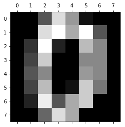

```
[[  0.   0.   5.  13.   9.   1.   0.   0.]
 [  0.   0.  13.  15.  10.  15.   5.   0.]
 [  0.   3.  15.   2.   0.  11.   8.   0.]
 [  0.   4.  12.   0.   0.   8.   8.   0.]
 [  0.   5.   8.   0.   0.   9.   8.   0.]
 [  0.   4.  11.   0.   1.  12.   7.   0.]
 [  0.   2.  14.   5.  10.  12.   0.   0.]
 [  0.   0.   6.  13.  10.   0.   0.   0.]]
```

```python
np.random.seed(42)
digits = load_digits()  # the whole dataset with the labels and other information are extracted
data = scale(digits.data)  # the data is scaled with the use of z-score
n_samples, n_features = data.shape  # the no. of samples and no. of features are determined with the help of shape
n_digits = len(np.unique(digits.target))  # the number of labels are determined with the aid of unique formula
labels = digits.target  # get the ground-truth labels into the labels

print(labels)
print(digits.keys())  # this command will provide you the key elements in this dataset
print(digits.DESCR)  # to get the descriptive information about this dataset

pl.gray()
pl.matshow(digits.images[0])
pl.show()
print(digits.images[0])
```

```python
from sklearn.model_selection import train_test_split  # some documents still include the cross-validation option but it no more exists in version 18.0
from sklearn.naive_bayes import GaussianNB
from sklearn.metrics import confusion_matrix
from sklearn.metrics import accuracy_score
import pylab as plt
y = digits.target
X = digits.data
X_train, X_test, y_train, y_test = train_test_split(X, y, test_size=0.3, random_state=10)
```

[output not shown]

```python
gnb = GaussianNB()
fit = gnb.fit(X_train, y_train)
predicted = fit.predict(X_test)
print(confusion_matrix(y_test, predicted))
print(accuracy_score(y_test, predicted)) # the use of another function for calculating the accuracy (correct_predictions / all_predictions)
print(accuracy_score(y_test, predicted, normalize=False))  # the number of correct predictions
print(len(predicted)) # number of all of the predictions
```

```
[[49  1  0  0  1  0  0  0  0  0]
 [ 0 53  1  0  0  0  0  0  3  0]
 [ 0  8 27  8  0  0  0  0 12  0]
 [ 0  0  0 51  0  0  0  1  3  1]
 [ 0  8  0  0 39  1  0  2  1  0]
 [ 0  0  0  1  0 46  0  3  1  0]
 [ 0  1  1  0  0  0 53  0  0  0]
 [ 0  0  0  0  1  0  0 59  0  0]
 [ 0 13  0  1  0  3  0  2 31  0]
 [ 0  2  0  7  0  1  1  9  3 31]]
0.812962962963
439
540
```

```python
gnb = GaussianNB()
fit2 = gnb.fit(X, y)
predictedx = fit2.predict(X)
print(confusion_matrix(y, predictedx))
print(accuracy_score(y, predictedx)) # the use of another function for calculating the accuracy (correct_predictions / all_predictions)
print(accuracy_score(y, predictedx, normalize=False))  # the number of correct predictions
print(len(predictedx))  # number of all of the predictions

unique_y, counts_y = np.unique(y, return_counts=True)
print(unique_y, counts_y)

unique_p, counts_p = np.unique(predictedx, return_counts=True)
print(unique_p, counts_p)
print((predictedx == 0).sum())
```

```
[[176   0   0   0   1   0   0   1   0   0]
 [  0 154   0   0   0   0   3   5  14   6]
 [  0  13 113   0   0   1   1   0  49   0]
 [  0   2   2 145   0   6   0   7  20   1]
 [  1   1   0   0 152   1   2  21   3   0]
 [  0   0   0   3   0 169   1   6   2   1]
 [  0   1   0   0   0   1 179   0   0   0]
 [  0   0   0   0   1   1   0 177   0   0]
 [  0   8   0   1   0   3   0  12 150   0]
 [  1   6   0   5   1   3   0  17  20 127]]
0.858096828047
1542
1797
[0 1 2 3 4 5 6 7 8 9] [178 182 177 183 181 182 181 179 174 180]
[0 1 2 3 4 5 6 7 8 9] [178 185 115 154 155 185 186 246 258 135]
178
```